# The Sampling Distribution of the Mean

## What is the Sampling Distribution of the Mean?

When we collect data, we usually work with a **sample** drawn from a larger **population**. The sample mean $\bar{x}$ is our best guess at the true population mean $\mu$, but it varies from sample to sample.

If we repeated our sampling process many times and recorded the mean each time, the distribution of those means is called the **sampling distribution of the mean**. Understanding its shape, centre, and spread is fundamental to statistical inference.

This notebook: 1. Generates a non-normal population so the results are more interesting 2. Draws 1,000 samples at three different sizes (small, medium, large) 3. Plots the resulting sampling distributions side by side 4. Shows how sample size affects the spread and shape

## Setup

```r
library(ggplot2)
library(dplyr)
library(tidyr)

set.seed(42)  # makes results reproducible
```

## Step 1 — Create the Population

We deliberately use a **right-skewed** population (a mixture of an exponential and a uniform distribution) so the population is clearly non-normal. This lets us see the Central Limit Theorem (CLT) at work as the sample size grows.

```r
N <- 100000  # population size

population <- c(
  rexp(N * 0.7, rate = 0.5),          # skewed component
  runif(N * 0.3, min = 5, max = 20)   # heavy right tail
)

pop_mean <- mean(population)
pop_sd   <- sd(population)

cat(sprintf("Population mean: %.2f\n", pop_mean))
```

```
## Population mean: 5.14
```

```r
cat(sprintf("Population SD:   %.2f\n", pop_sd))
```

```
## Population SD:   5.61
```

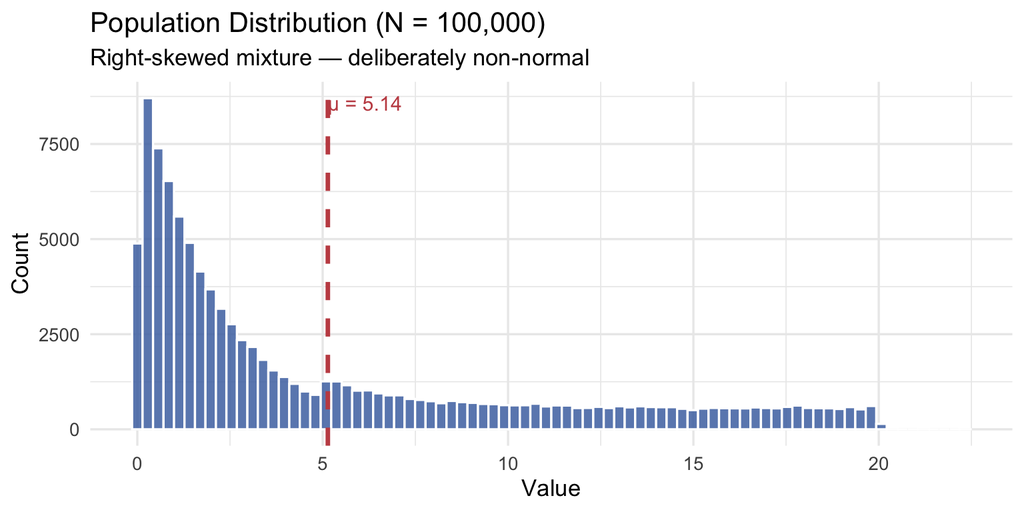

```r
ggplot(data.frame(x = population), aes(x = x)) +
  geom_histogram(bins = 80, fill = "#4C72B0", colour = "white", alpha = 0.85) +
  geom_vline(xintercept = pop_mean, colour = "#C44E52", linewidth = 1.2, linetype = "dashed") +
  annotate("text", x = pop_mean + 1, y = Inf, vjust = 2,
           label = paste0("μ = ", round(pop_mean, 2)), colour = "#C44E52", size = 4) +
  labs(
    title = "Population Distribution (N = 100,000)",
    subtitle = "Right-skewed mixture — deliberately non-normal",
    x = "Value", y = "Count"
  ) +
  theme_minimal(base_size = 13)
```

**What you see:** The population is clearly right-skewed — not bell-shaped. Keep this shape in mind as you compare it to the sampling distributions below.

## Step 2 — Draw 1,000 Samples at Three Sample Sizes

We repeat the following 1,000 times for each sample size: - Pick *n* observations at random (with replacement) from the population - Record the mean of those *n* observations

```r
n_simulations <- 1000
sample_sizes  <- c(small = 5, medium = 30, large = 200)

# For each sample size, collect 1000 sample means
results <- lapply(names(sample_sizes), function(label) {
  n <- sample_sizes[[label]]
  means <- replicate(n_simulations, mean(sample(population, size = n, replace = TRUE)))
  data.frame(
    sample_size = label,
    n           = n,
    sample_mean = means
  )
})

sim_df <- bind_rows(results) %>%
  mutate(sample_size = factor(sample_size, levels = c("small", "medium", "large")))

# Theoretical standard error for each size: σ / √n
se_df <- data.frame(
  sample_size = factor(names(sample_sizes), levels = c("small", "medium", "large")),
  n           = unname(sample_sizes),
  theoretical_se = pop_sd / sqrt(unname(sample_sizes))
)

head(sim_df)
```

```
##   sample_size n sample_mean
## 1       small 5    3.475052
## 2       small 5    3.958311
## 3       small 5    2.546732
## 4       small 5    5.867354
## 5       small 5    0.383674
## 6       small 5    6.371971
```

## Step 3 — Plot the Sampling Distributions

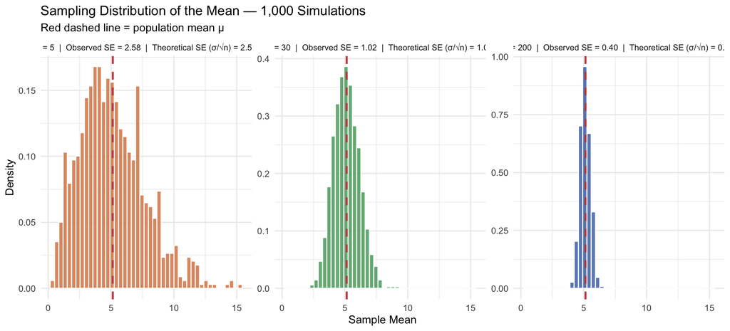

```r
# Labels for facets showing actual SE from simulation
facet_labels <- sim_df %>%
  group_by(sample_size, n) %>%
  summarise(observed_se = sd(sample_mean), .groups = "drop") %>%
  left_join(se_df, by = c("sample_size", "n")) %>%
  mutate(label = sprintf(
    "n = %d  |  Observed SE = %.2f  |  Theoretical SE (σ/√n) = %.2f",
    n, observed_se, theoretical_se
  ))

label_vec <- setNames(facet_labels$label, facet_labels$sample_size)

ggplot(sim_df, aes(x = sample_mean, fill = sample_size)) +
  geom_histogram(aes(y = after_stat(density)), bins = 45,
                 colour = "white", alpha = 0.85) +
  geom_vline(xintercept = pop_mean, colour = "#C44E52", linewidth = 1, linetype = "dashed") +
  facet_wrap(~ sample_size, scales = "free_y",
             labeller = labeller(sample_size = label_vec)) +
  scale_fill_manual(values = c(small = "#DD8452", medium = "#55A868", large = "#4C72B0")) +
  labs(
    title    = "Sampling Distribution of the Mean — 1,000 Simulations",
    subtitle = "Red dashed line = population mean μ",
    x = "Sample Mean", y = "Density",
    fill = "Sample size"
  ) +
  theme_minimal(base_size = 12) +
  theme(legend.position = "none", strip.text = element_text(size = 9))
```

## Step 4 — Comparing the Spread Across Sample Sizes

The standard error (SE) measures the spread of the sampling distribution. Theory predicts $SE = \sigma / \sqrt{n}$.

```r
sim_df %>%
  group_by(sample_size, n) %>%
  summarise(
    mean_of_means  = round(mean(sample_mean), 3),
    observed_SE    = round(sd(sample_mean), 3),
    theoretical_SE = round(pop_sd / sqrt(n[1]), 3),
    .groups = "drop"
  )
```

```
## # A tibble: 3 × 5
##   sample_size     n mean_of_means observed_SE theoretical_SE
##   <fct>       <dbl>         <dbl>       <dbl>          <dbl>
## 1 small           5          5.11       2.58           2.51
## 2 medium         30          5.12       1.02           1.02
## 3 large         200          5.13       0.396          0.397
```

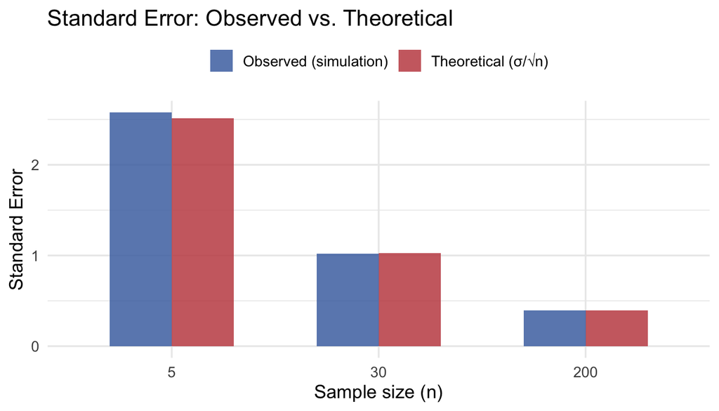

```r
se_summary <- sim_df %>%
  group_by(sample_size, n) %>%
  summarise(observed_SE = sd(sample_mean), .groups = "drop") %>%
  left_join(se_df, by = c("sample_size", "n")) %>%
  pivot_longer(cols = c(observed_SE, theoretical_se),
               names_to = "type", values_to = "SE") %>%
  mutate(type = recode(type,
    observed_SE    = "Observed (simulation)",
    theoretical_se = "Theoretical (σ/√n)"
  ))

ggplot(se_summary, aes(x = factor(n), y = SE, fill = type)) +
  geom_col(position = "dodge", alpha = 0.85, width = 0.6) +
  scale_fill_manual(values = c("Observed (simulation)" = "#4C72B0",
                               "Theoretical (σ/√n)"    = "#C44E52")) +
  labs(
    title = "Standard Error: Observed vs. Theoretical",
    x = "Sample size (n)", y = "Standard Error", fill = NULL
  ) +
  theme_minimal(base_size = 13) +
  theme(legend.position = "top")
```

**What you see:** Observed SEs closely match the theoretical formula. Doubling $n$ does *not* halve the SE — you need to **quadruple** $n$ to halve it (because of the $\sqrt{n}$ denominator).

## Step 5 — Watching Normality Emerge (Central Limit Theorem)

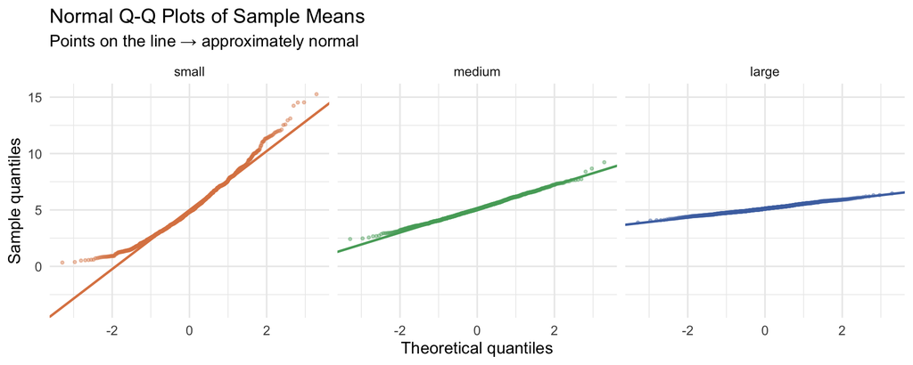

```r
ggplot(sim_df, aes(sample = sample_mean, colour = sample_size)) +
  stat_qq(alpha = 0.4, size = 0.8) +
  stat_qq_line(linewidth = 0.9) +
  facet_wrap(~ sample_size) +
  scale_colour_manual(values = c(small = "#DD8452", medium = "#55A868", large = "#4C72B0")) +
  labs(
    title    = "Normal Q-Q Plots of Sample Means",
    subtitle = "Points on the line → approximately normal",
    x = "Theoretical quantiles", y = "Sample quantiles"
  ) +
  theme_minimal(base_size = 13) +
  theme(legend.position = "none")
```

**What you see:** With $n = 5$ the tails bend away from the line, showing the skewness inherited from the population. By $n = 30$ the fit is already excellent, and by $n = 200$ it is nearly perfect — this is the **Central Limit Theorem** in action.

## Key Takeaways

| Concept | Plain-English Meaning |
| --- | --- |
| **Sampling distribution** | The distribution of a statistic (here: the mean) across many repeated samples |
| **Standard error** | The standard deviation of the sampling distribution; measures how much $\bar{x}$ bounces around |
| **$SE = \sigma / \sqrt{n}$** | Larger samples produce more precise estimates — but with diminishing returns |
| **Central Limit Theorem** | Regardless of the population’s shape, the sampling distribution of the mean approaches normal as $n$ grows |
| **Unbiasedness** | The mean of all sample means equals the true population mean $\mu$ |

> **Rule of thumb:** $n \geq 30$ is often enough for the CLT to kick in for moderately skewed populations. Heavily skewed or multi-modal populations may need larger $n$.